# Time Series Modeling of the S&P 500 Index

# Objectives

The price data is obtained using the quantmod R package.

```r
library("quantmod")
getSymbols("^GSPC", from="2010-1-1")
```

```
[1] "GSPC"
```

```r
head(GSPC)
```

```
           GSPC.Open GSPC.High GSPC.Low GSPC.Close GSPC.Volume GSPC.Adjusted
2010-01-04   1116.56   1133.87  1116.56    1132.99  3991400000       1132.99
2010-01-05   1132.66   1136.63  1129.66    1136.52  2491020000       1136.52
2010-01-06   1135.71   1139.19  1133.95    1137.14  4972660000       1137.14
2010-01-07   1136.27   1142.46  1131.32    1141.69  5270680000       1141.69
2010-01-08   1140.52   1145.39  1136.22    1144.98  4389590000       1144.98
2010-01-11   1145.96   1149.74  1142.02    1146.98  4255780000       1146.98
```

There are different types of available data. The adjusted close price is used in the price modeling in this analysis. It would be easier to visualize the adjusted close price with a plot.

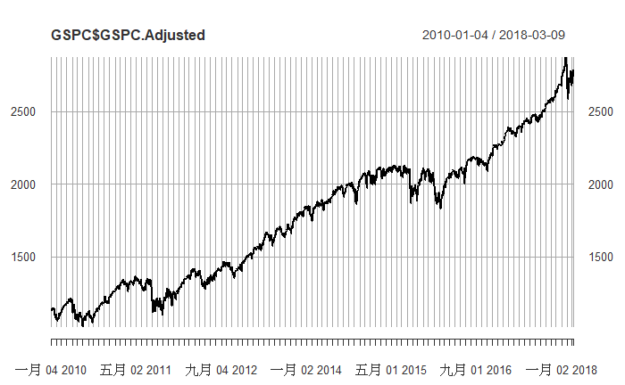

```r
plot(GSPC$GSPC.Adjusted)
```

The plot of the adjusted price shows a generally increasing trend from 2010 to the early Mar 2018. Moreover, non-constant variance and non-constant mean are observed in this plot. I am curious to check if the adjusted price time series is stationary. Stationarity of a time series is very important to using ARIMA as the modeling technique.

To check for the stationarity of a time series, the Augmented Dickey-Fuller statistical test is performed.

```r
library("tseries")
adf.test(GSPC$GSPC.Adjusted)
```

```
    Augmented Dickey-Fuller Test

data:  GSPC$GSPC.Adjusted
Dickey-Fuller = -2.547, Lag order = 12, p-value = 0.3468
alternative hypothesis: stationary
```

Since the p-value is large (compared to 0.05 at 95% confidence interval), the null hypothesis cannot be rejected. Thus, the time series is not stationary.

I am also curious to check if there is severe autocorrelation in this time series by using the autocorrelation function plot.

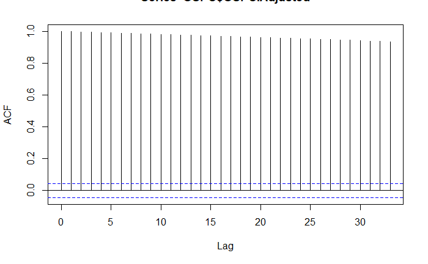

```r
acf(GSPC$GSPC.Adjusted)
```

Since all peaks exceed the 95% confidence interval bands, autocorrelation is severe in this time series.

I’d like to recap the problems observed so far for the adjusted price time series. 1. Non-constant mean 2. Non-constant variance 3. Non-stationary 4. Severe autocorrelation

The first problem can be solved by applying a first order differencing. By differencing the adjusted close price time series, the time series of return is obtained. The return time series is then plotted.

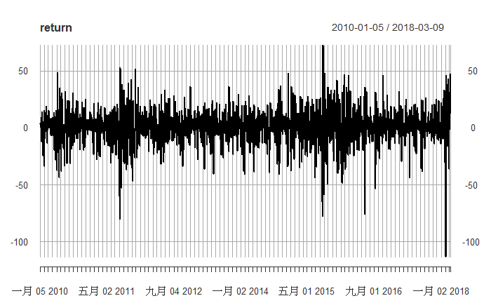

```r
return <- diff(GSPC$GSPC.Adjusted)
return <- return[-1]
names(return) <- c("Return")
plot(return)
```

By inspecting this time series, it has approximately a constant mean and a constant variance.

The next step is to investigate the autocorrelation in this time series.

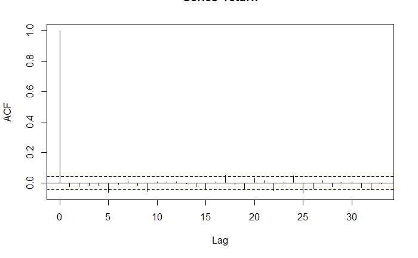

```r
acf(return)
```

Before proceeding, I am going to partition this time series into the training set (80%) and the testing set (20%).

```r
nrow(return)
```

[output not shown]

The total number of rows of the price data is 2059.

```r
#Split the data into training set (80%) and data set (20%)
ts.train <- return[1:1647,] # 80%
ts.test <- return[1647:2059,] #20%
```

```r
head(ts.train)
head(ts.test)
```

[output not shown]

Since the training set will be used for building up the ARIMA model, it is important for it to be stationary. The Augmented Dickey-Fuller test is performed again to check if the time series is stationary.

```r
adf.test(ts.train)
```

[output not shown]

Since the p-value < 0.05 at 95% confidence interval, the null hypothesis is rejected and the alternative hypothesis is accepted. Thus, it is very likely to be a stationary time series.

Next, the forecast R library is loaded in order to perform the ARIMA modeling. In terms of the selection of the AR and MA orders, auto.arima() is employed to building the ARIMA model using the training set and to find out the combination of those orders which gives the smallest AIC value.

```r
library("forecast")
model <- auto.arima(ts.train)
summary(model)
```

[output not shown]

(p,d,q) = (2,0,2) as a result of the determination of the orders

The next step is to evaluate the ARIMA fitting results and this is done by inspecting the residuals.

```r
checkresiduals(model)
```

[output not shown]

The top plot does not show any pattern and it resembles white noise, which are great. The ACF plot shows that this time series is roughly not correlated except at lags 24 and 25. The distribution plot shows that the distribution of the residuals is not quite normally distributed. The Shapiro-Wilk normality test is then used to check if the residuals are distributed normally.

```r
shapiro.test(model$residuals)
```

[output not shown]

Since the p-value is < 0.05 at 95% confidence interval, the null hypothesis is rejected and the alternative hypothesis is accepted. Thus, the residuals are not normally distributed.

Let’s run a forecast model based on the existing fitted ARIMA model for 40 days.

```r
return.forecast <- forecast(model, h=40)
plot(return.forecast)
```

[output not shown]

The ARIMA model predicts a generally increasing trend for the next 40 days. Let’s compare this prediction with the actual results.

```r
plot(ts.test[1:40])
```

[output not shown]

The actual time series is decreasing.

# Conclusion

There is a significant discrepancy between the predicted return and the actual return of S&P 500 in the same time period.

The possible sources of errors of this analysis are:

1. The residuals of the ARIMA model are not normally distributed.
2. There are many factors that can affect the increase/decrease of return, which are not accounted for in this analysis.